# TUGAS MPDW ARGADO

ARGADO SAMUEL PANOGU

2025-07-31

```r
library("forecast")
```

```r
library("graphics")
library("TTR")
library(ggplot2)
library(readxl)
library(rio)
```

## Mengimport Data

```r
datasales<- read_excel("C:/Users/Argado Samuel Panogu/Downloads/dataaa.xlsx")
datasales
```

```
## # A tibble: 730 × 2
##    Date                Total_Sales
##    <dttm>                    <dbl>
##  1 2022-01-01 00:00:00        185.
##  2 2022-01-02 00:00:00        193.
##  3 2022-01-03 00:00:00        213.
##  4 2022-01-04 00:00:00        250.
##  5 2022-01-05 00:00:00        224.
##  6 2022-01-06 00:00:00        222.
##  7 2022-01-07 00:00:00        200.
##  8 2022-01-08 00:00:00        213.
##  9 2022-01-09 00:00:00        222.
## 10 2022-01-10 00:00:00        203.
## # ℹ 720 more rows
```

### Mengambil 100 Data

```r
datani <- datasales[201:300,]
datani
```

```
## # A tibble: 100 × 2
##    Date                Total_Sales
##    <dttm>                    <dbl>
##  1 2022-07-20 00:00:00        267.
##  2 2022-07-21 00:00:00        229.
##  3 2022-07-22 00:00:00        212.
##  4 2022-07-23 00:00:00        189.
##  5 2022-07-24 00:00:00        195.
##  6 2022-07-25 00:00:00        248.
##  7 2022-07-26 00:00:00        233.
##  8 2022-07-27 00:00:00        237.
##  9 2022-07-28 00:00:00        273.
## 10 2022-07-29 00:00:00        240.
## # ℹ 90 more rows
```

## Eksplorasi Data

```r
str(datani)
```

```
## tibble [100 × 2] (S3: tbl_df/tbl/data.frame)
##  $ Date       : POSIXct[1:100], format: "2022-07-20" "2022-07-21" ...
##  $ Total_Sales: num [1:100] 267 229 212 189 195 ...
```

```r
dim(datani)
```

```
## [1] 100   2
```

### Memeriksa apakah ada tanggal kosong

```r
datani$Date <- as.Date(datani$Date)
all_dates <- seq(min(datani$Date), max(datani$Date), by = "day")
missing_dates <- setdiff(all_dates, datani$Date)
missing_dates
```

```
## numeric(0)
```

### Mengubah data agar terbaca sebagai data deret waktu

```r
data.ts <- ts(datani$Total_Sales)
```

### Hasil Ringkasan Data

```r
summary(data.ts)
```

```
##    Min. 1st Qu.  Median    Mean 3rd Qu.    Max.
##   188.7   209.7   226.7   227.2   238.7   280.9
```

### Plot Data Deret Waktu

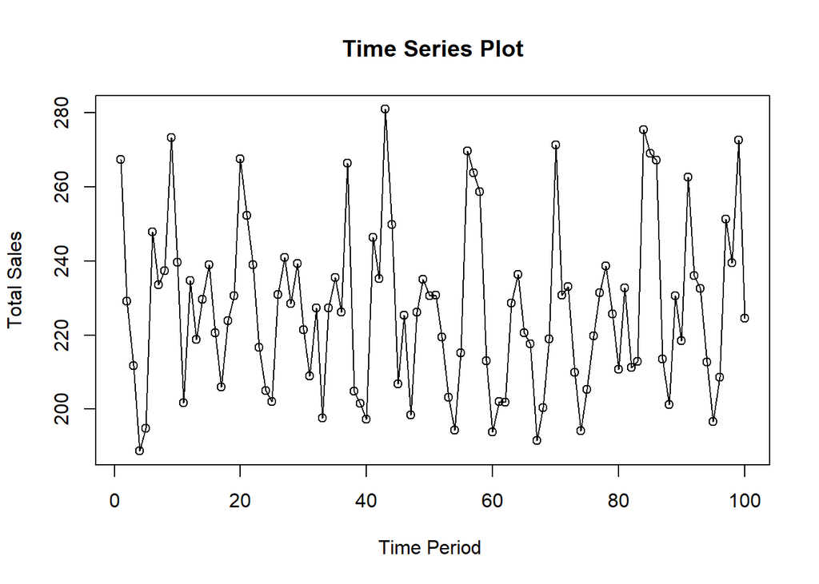

```r
ts.plot(data.ts, xlab="Time Period ", ylab="Total Sales",
        main = "Time Series Plot")
points(data.ts)
```

## Metode Single Moving Average

### Membagi Data

Membagi data latih dan data uji dengan perbandingan 80% data latih dan 20% data uji.

```r
# hitung jumlah data
n <- nrow(datani)

# tentukan batas 80%
n_train <- floor(0.8 * n)

# bagi data
training_ma <- datani[1:n_train, ]
testing_ma  <- datani[(n_train+1):n, ]

# ubah ke time series
train_ma.ts <- ts(training_ma$Total_Sales)
test_ma.ts  <- ts(testing_ma$Total_Sales)
```

### Hasil plot data train

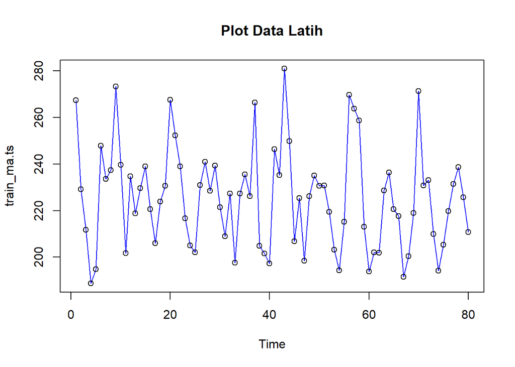

```r
plot(train_ma.ts, col="blue",main="Plot Data Latih")
points(train_ma.ts)
```

### Hasil plot data test

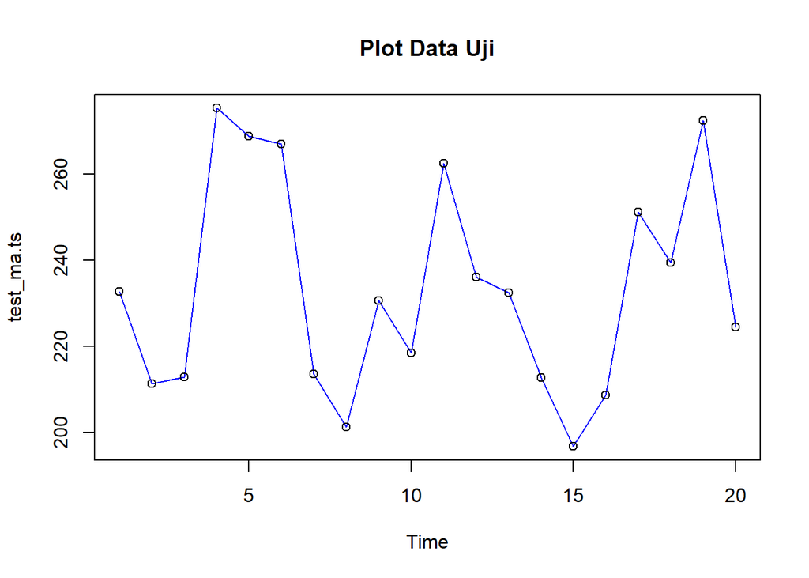

```r
plot(test_ma.ts, col="blue",main="Plot Data Uji")
points(test_ma.ts)
```

### Hasil plot semua data

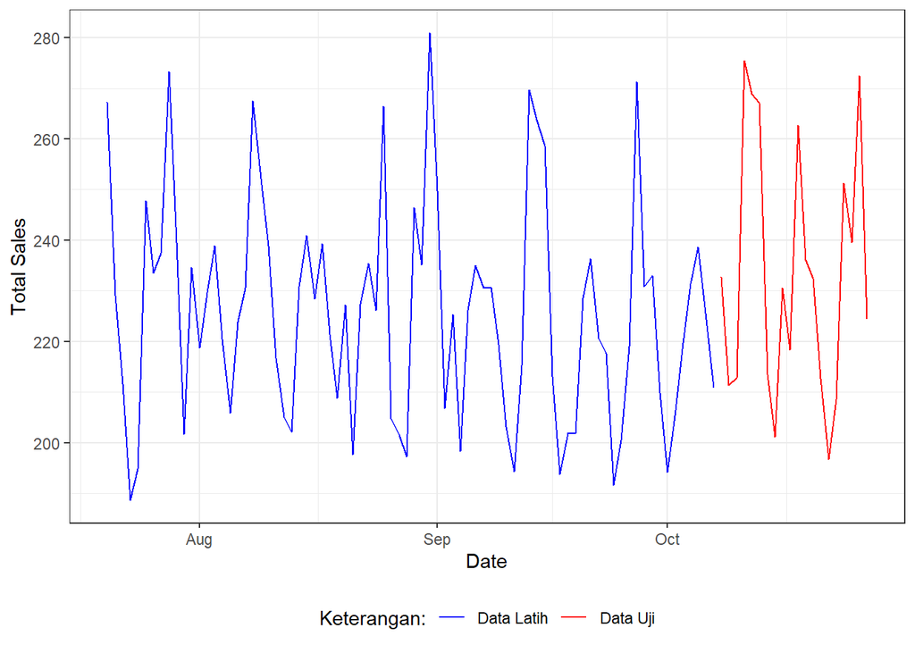

```r
ggplot() +
  geom_line(data = training_ma, aes(x = Date, y = Total_Sales, col = "Data Latih")) +
  geom_line(data = testing_ma, aes(x = Date, y = Total_Sales, col = "Data Uji")) +
  labs(x = "Date", y = "Total Sales", color = "Legend") +
   scale_colour_manual(name="Keterangan:", breaks = c("Data Latih", "Data Uji"),
                      values = c("blue", "red")) +
  theme_bw() + theme(legend.position = "bottom",
                     plot.caption = element_text(hjust=0.5, size=12))
```

```r
data.sma<-SMA(train_ma.ts, n=4)
data.sma
```

```
## Time Series:
## Start = 1
## End = 80
## Frequency = 1
##  [1]       NA       NA       NA 224.1925 206.0850 210.7550 216.2075 228.3725
##  [9] 247.9900 245.9400 237.9850 237.3000 223.6775 221.2000 230.5275 226.9975
## [17] 223.7700 222.3225 220.2425 231.9825 243.5725 247.3375 243.8475 228.2450
## [25] 215.7050 213.6925 219.7425 225.5675 234.8550 232.4900 224.4875 224.2050
## [33] 213.8075 215.2825 221.9325 221.6425 238.8200 233.1925 224.7325 217.5400
## [41] 212.5425 220.1300 239.9450 253.0625 243.1700 240.7100 220.0775 214.1650
## [49] 221.2175 222.5350 230.6275 228.9550 221.0050 211.9475 208.0775 220.6375
## [57] 235.7625 251.8450 251.2975 232.3200 216.8950 202.6700 206.5500 217.1925
## [65] 221.8375 225.8100 216.5700 207.6025 207.2050 220.5950 230.3875 238.5200
## [73] 236.2500 216.9875 210.6250 207.3000 212.6650 223.7775 228.8475 226.6225
```

Data pemulusan pada periode ke-t selanjutnya digunakan sebagai nilai peramalan pada periode ke t+1 sehingga hasil peramalan 1 periode kedepan adalah sebagai berikut.

```r
data.ramal<-c(NA,data.sma)
data.ramal #forecast 1 periode ke depan
```

```
##  [1]       NA       NA       NA       NA 224.1925 206.0850 210.7550 216.2075
##  [9] 228.3725 247.9900 245.9400 237.9850 237.3000 223.6775 221.2000 230.5275
## [17] 226.9975 223.7700 222.3225 220.2425 231.9825 243.5725 247.3375 243.8475
## [25] 228.2450 215.7050 213.6925 219.7425 225.5675 234.8550 232.4900 224.4875
## [33] 224.2050 213.8075 215.2825 221.9325 221.6425 238.8200 233.1925 224.7325
## [41] 217.5400 212.5425 220.1300 239.9450 253.0625 243.1700 240.7100 220.0775
## [49] 214.1650 221.2175 222.5350 230.6275 228.9550 221.0050 211.9475 208.0775
## [57] 220.6375 235.7625 251.8450 251.2975 232.3200 216.8950 202.6700 206.5500
## [65] 217.1925 221.8375 225.8100 216.5700 207.6025 207.2050 220.5950 230.3875
## [73] 238.5200 236.2500 216.9875 210.6250 207.3000 212.6650 223.7775 228.8475
## [81] 226.6225
```

Selanjutnya dilakukan peramalan sebanyak 20 periode sesuai dengan jumlah data uji. Pada metode SMA, seluruh hasil peramalan untuk 20 periode ke depan akan memiliki nilai yang sama dengan hasil ramalan satu periode ke depan.

```r
data.gab<-cbind(
  aktual=c(data.ts),
  pemulusan=c(data.sma,rep(NA,20)),
  ramalan=c(data.ramal,rep(data.ramal[length(data.ramal)],19)))

data.gab #forecast 20 periode ke depan
```

```
##        aktual pemulusan  ramalan
##   [1,] 267.27        NA       NA
##   [2,] 229.11        NA       NA
##   [3,] 211.66        NA       NA
##   [4,] 188.73  224.1925       NA
##   [5,] 194.84  206.0850 224.1925
##   [6,] 247.79  210.7550 206.0850
##   [7,] 233.47  216.2075 210.7550
##   [8,] 237.39  228.3725 216.2075
##   [9,] 273.31  247.9900 228.3725
##  [10,] 239.59  245.9400 247.9900
##  [11,] 201.65  237.9850 245.9400
##  [12,] 234.65  237.3000 237.9850
##  [13,] 218.82  223.6775 237.3000
##  [14,] 229.68  221.2000 223.6775
```

[output cut: 86 more lines]

Adapun plot data deret waktu dari hasil peramalan yang dilakukan adalah sebagai berikut.

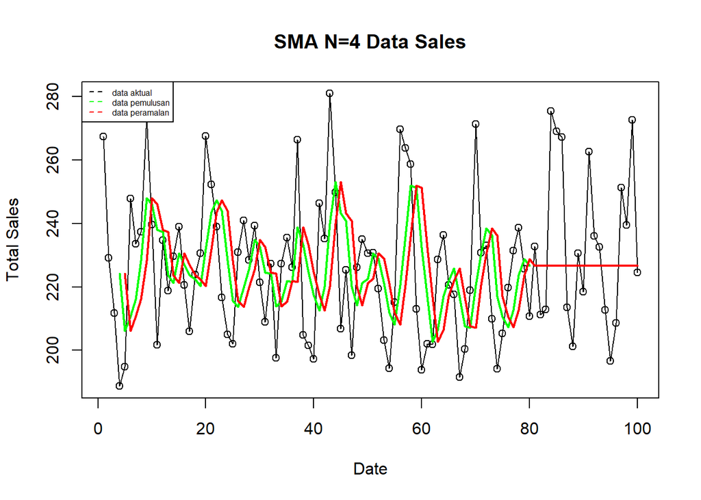

```r
ts.plot(data.ts, xlab="Date", ylab="Total Sales", main= "SMA N=4 Data Sales")
points(data.ts)
lines(data.gab[,2],col="green",lwd=2)
lines(data.gab[,3],col="red",lwd=2)
legend("topleft",c("data aktual","data pemulusan","data peramalan"), lty=8, col=c("black","green","red"), cex=0.5)
```

Selanjutnya perhitungan akurasi dilakukan dengan ukuran akurasi Sum Squares Error (SSE), Mean Square Error (MSE) dan Mean Absolute Percentage Error (MAPE). Perhitungan akurasi dilakukan baik pada data latih maupun pada data uji.

```r
#Menghitung nilai keakuratan data latih
error_train.sma = train_ma.ts-data.ramal[1:length(train_ma.ts)]

SSE_train.sma = sum(error_train.sma[5:length(train_ma.ts)]^2)
MSE_train.sma = mean(error_train.sma[5:length(train_ma.ts)]^2)
MAPE_train.sma = mean(abs((error_train.sma[5:length(train_ma.ts)]/train_ma.ts[5:length(train_ma.ts)])*100))

akurasi_train.sma <- matrix(c(SSE_train.sma, MSE_train.sma, MAPE_train.sma))
row.names(akurasi_train.sma)<- c("SSE", "MSE", "MAPE")
colnames(akurasi_train.sma) <- c("Akurasi m = 4")
akurasi_train.sma
```

```
##      Akurasi m = 4
## SSE    58322.61054
## MSE      767.40277
## MAPE      10.20513
```

```r
#Menghitung nilai keakuratan data uji
error_test.sma = test_ma.ts-data.gab[81:100,3]

SSE_test.sma = sum(error_test.sma^2)
MSE_test.sma = mean(error_test.sma^2)
MAPE_test.sma = mean(abs((error_test.sma/test_ma.ts*100)))

akurasi_test.sma <- matrix(c(SSE_test.sma, MSE_test.sma, MAPE_test.sma))
row.names(akurasi_test.sma)<- c("SSE", "MSE", "MAPE")
colnames(akurasi_test.sma) <- c("Akurasi m = 4")
akurasi_test.sma
```

```
##      Akurasi m = 4
## SSE   12893.776975
## MSE     644.688849
## MAPE      8.643479
```

## Metode Single Exponential Smoothing

```r
# jumlah baris data
n <- nrow(datani)

# hitung batas 80%
n_train <- floor(0.8 * n)

# bagi data
training <- datani[1:n_train, ]
testing  <- datani[(n_train+1):n, ]

# ubah ke time series
train.ts <- ts(training$Total_Sales)
test.ts  <- ts(testing$Total_Sales)
```

### Hasil plot data train

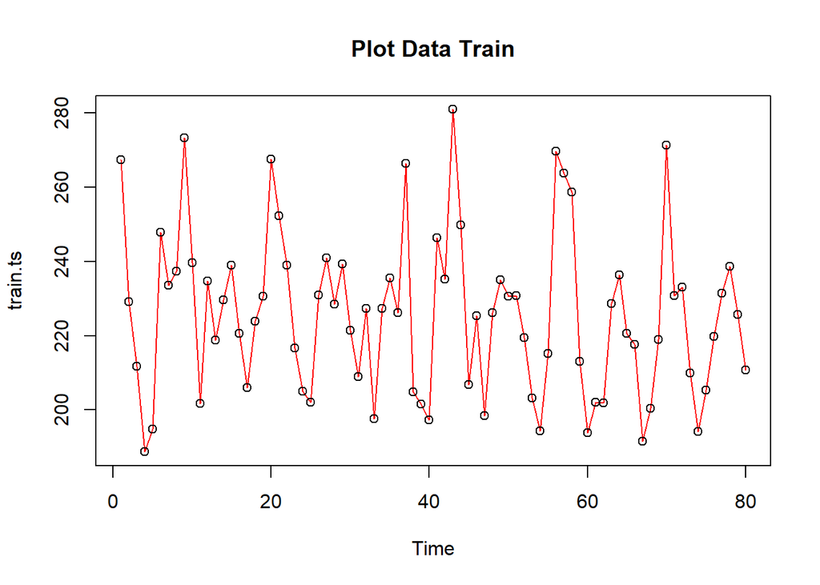

```r
plot(train.ts, col="red",main="Plot Data Train")
points(train.ts)
```

### Hasil plot data test

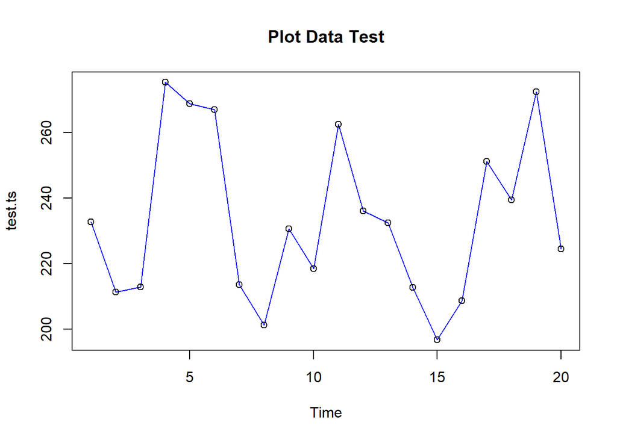

```r
plot(test.ts, col="blue",main="Plot Data Test")
points(test.ts)
```

### Hasil plot semua data

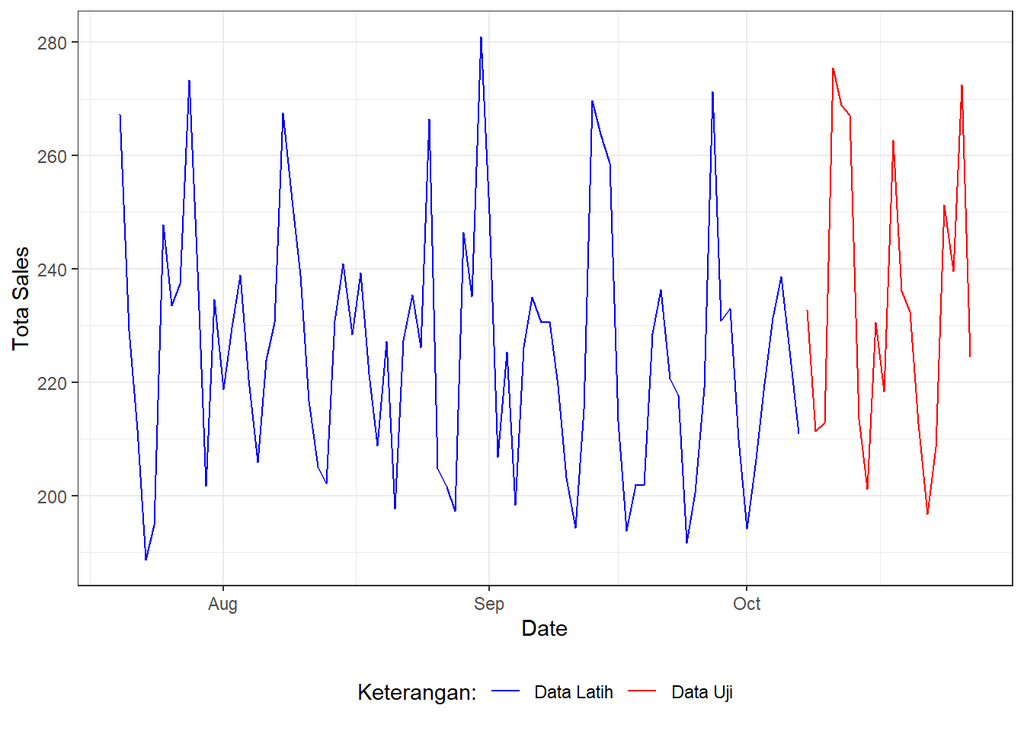

```r
library(ggplot2)
ggplot() +
  geom_line(data = training, aes(x = Date, y = Total_Sales, col = "Data Latih")) +
  geom_line(data = testing, aes(x = Date, y = Total_Sales, col = "Data Uji")) +
  labs(x = "Date", y = "Tota Sales", color = "Legend") +
  scale_colour_manual(name="Keterangan:", breaks = c("Data Latih", "Data Uji"),
                      values = c("blue", "red")) +
  theme_bw() + theme(legend.position = "bottom",
                     plot.caption = element_text(hjust=0.5, size=12))
```

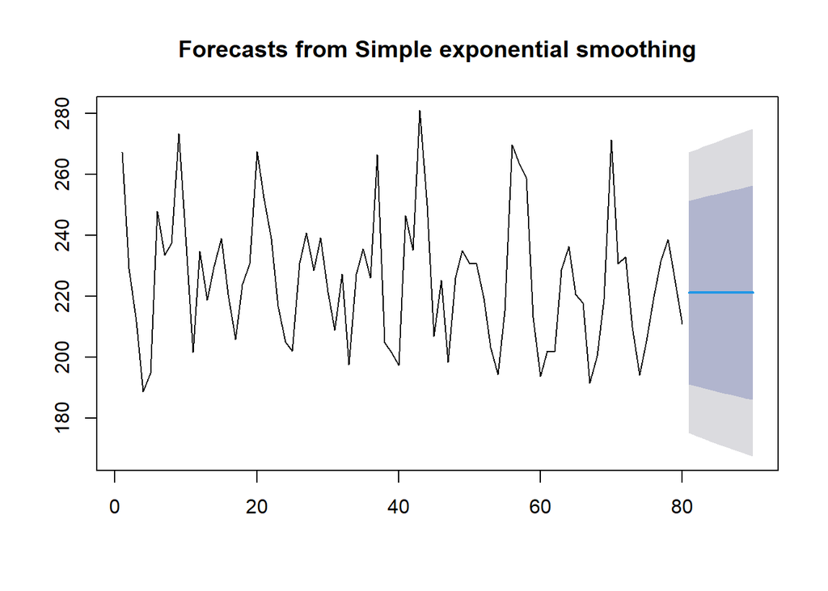

```r
#Cara 1 (fungsi ses)
ses.1 <- ses(train.ts, h = 10, alpha = 0.2)
plot(ses.1)
```

```r
ses.1
```

```
##    Point Forecast    Lo 80    Hi 80    Lo 95    Hi 95
## 81       221.1536 191.0488 251.2583 175.1123 267.1948
## 82       221.1536 190.4526 251.8545 174.2005 268.1066
## 83       221.1536 189.8678 252.4393 173.3061 269.0010
## 84       221.1536 189.2937 253.0134 172.4281 269.8790
## 85       221.1536 188.7298 253.5774 171.5656 270.7415
## 86       221.1536 188.1755 254.1316 170.7179 271.5892
## 87       221.1536 187.6303 254.6768 169.8842 272.4229
## 88       221.1536 187.0939 255.2132 169.0638 273.2433
## 89       221.1536 186.5658 255.7413 168.2562 274.0509
## 90       221.1536 186.0457 256.2614 167.4607 274.8464
```

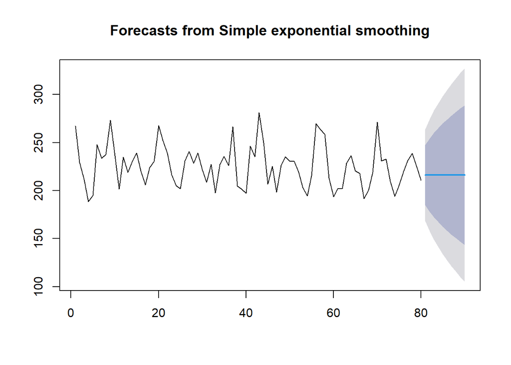

```r
ses.2<- ses(train.ts, h = 10, alpha = 0.7)
plot(ses.2)
```

```r
ses.2
```

```
##    Point Forecast    Lo 80    Hi 80    Lo 95    Hi 95
## 81       216.0979 184.8730 247.3228 168.3436 263.8522
## 82       216.0979 177.9831 254.2127 157.8063 274.3895
## 83       216.0979 172.1606 260.0352 148.9016 283.2942
## 84       216.0979 167.0242 265.1716 141.0461 291.1497
## 85       216.0979 162.3766 269.8192 133.9383 298.2575
## 86       216.0979 158.1003 274.0955 127.3982 304.7976
## 87       216.0979 154.1183 278.0775 121.3083 310.8875
## 88       216.0979 150.3772 281.8186 115.5867 316.6091
## 89       216.0979 146.8378 285.3580 110.1737 322.0221
## 90       216.0979 143.4707 288.7251 105.0242 327.1716
```

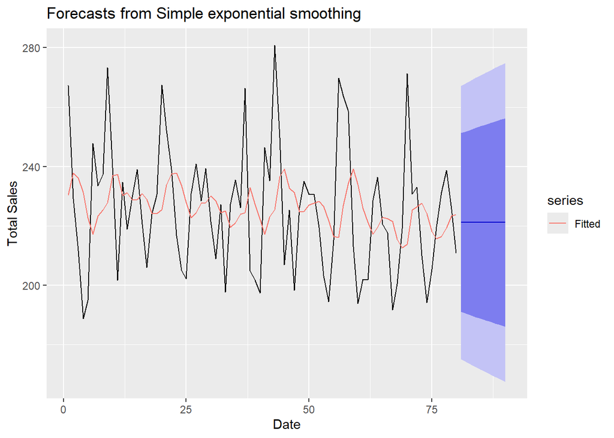

```r
autoplot(ses.1) +
  autolayer(fitted(ses.1), series="Fitted") +
  ylab("Total Sales") + xlab("Date")
```

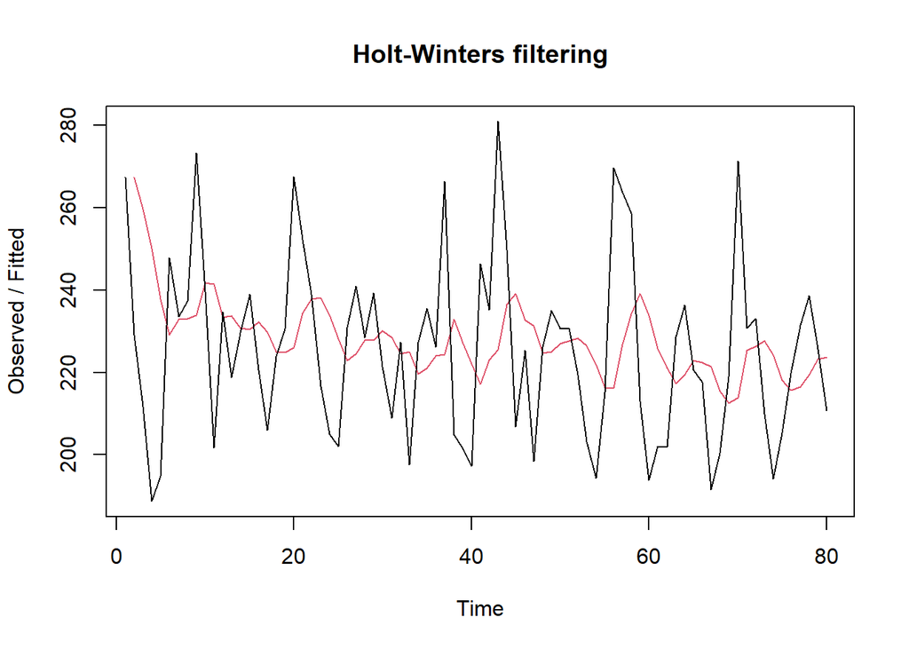

```r
#Cara 2 (fungsi Holtwinter)
ses1<- HoltWinters(train.ts, gamma = FALSE, beta = FALSE, alpha = 0.2)
plot(ses1)
```

```r
#ramalan
ramalan1<- forecast(ses1, h=10)
ramalan1
```

```
##    Point Forecast    Lo 80    Hi 80    Lo 95    Hi 95
## 81       221.1536 189.9886 252.3185 173.4909 268.8162
## 82       221.1536 189.3714 252.9357 172.5470 269.7601
## 83       221.1536 188.7660 253.5411 171.6210 270.6861
## 84       221.1536 188.1717 254.1354 170.7121 271.5950
## 85       221.1536 187.5879 254.7192 169.8193 272.4878
## 86       221.1536 187.0141 255.2931 168.9417 273.3654
## 87       221.1536 186.4497 255.8574 168.0786 274.2285
## 88       221.1536 185.8944 256.4127 167.2294 275.0777
## 89       221.1536 185.3477 256.9594 166.3933 275.9138
## 90       221.1536 184.8093 257.4978 165.5698 276.7373
```

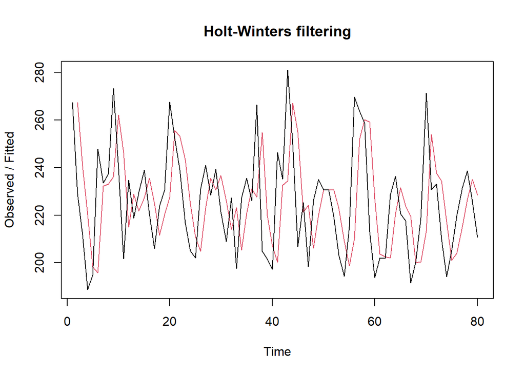

```r
ses2<- HoltWinters(train.ts, gamma = FALSE, beta = FALSE, alpha = 0.7)
plot(ses2)
```

```r
#ramalan
ramalan2<- forecast(ses2, h=10)
ramalan2
```

```
##    Point Forecast    Lo 80    Hi 80    Lo 95    Hi 95
## 81       216.0979 184.8287 247.3671 168.2757 263.9201
## 82       216.0979 177.9289 254.2669 157.7235 274.4723
## 83       216.0979 172.0982 260.0976 148.8062 283.3896
## 84       216.0979 166.9545 265.2414 140.9395 291.2563
## 85       216.0979 162.3003 269.8955 133.8216 298.3743
## 86       216.0979 158.0179 274.1779 127.2722 304.9236
## 87       216.0979 154.0303 278.1656 121.1736 311.0222
## 88       216.0979 150.2838 281.9120 115.4439 316.7519
## 89       216.0979 146.7394 285.4564 110.0232 322.1726
## 90       216.0979 143.3675 288.8283 104.8664 327.3294
```

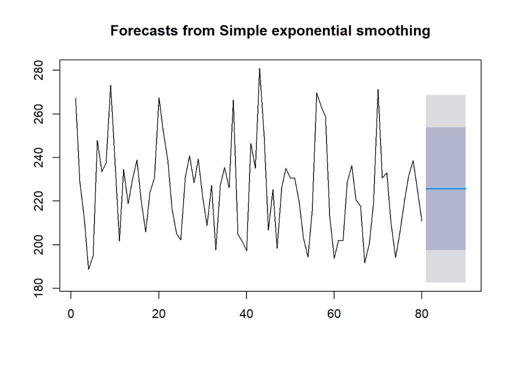

```r
#SES
ses.opt <- ses(train.ts, h = 10, alpha = NULL)
plot(ses.opt)
```

```r
ses.opt
```

```
##    Point Forecast    Lo 80    Hi 80    Lo 95    Hi 95
## 81        225.623 197.4591 253.7869 182.5501 268.6959
## 82        225.623 197.4591 253.7869 182.5501 268.6959
## 83        225.623 197.4591 253.7869 182.5501 268.6959
## 84        225.623 197.4591 253.7869 182.5501 268.6959
## 85        225.623 197.4591 253.7869 182.5501 268.6959
## 86        225.623 197.4591 253.7869 182.5501 268.6959
## 87        225.623 197.4591 253.7869 182.5501 268.6959
## 88        225.623 197.4591 253.7869 182.5501 268.6959
## 89        225.623 197.4591 253.7869 182.5501 268.6959
## 90        225.623 197.4591 253.7869 182.5501 268.6959
```

```r
#Lamda Optimum Holt Winter
HWopt<- HoltWinters(train.ts, gamma = FALSE, beta = FALSE,alpha = NULL)
HWopt
```

```
## Holt-Winters exponential smoothing without trend and without seasonal component.
##
## Call:
## HoltWinters(x = train.ts, alpha = NULL, beta = FALSE, gamma = FALSE)
##
## Smoothing parameters:
##  alpha: 0.803065
##  beta : FALSE
##  gamma: FALSE
##
## Coefficients:
##       [,1]
## a 214.1546
```

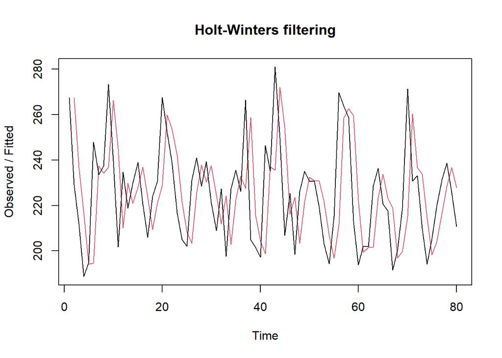

```r
plot(HWopt)
```

```r
#ramalan
ramalanopt<- forecast(HWopt, h=10)
ramalanopt
```

```
##    Point Forecast    Lo 80    Hi 80     Lo 95    Hi 95
## 81       214.1546 182.9520 245.3573 166.43426 261.8750
## 82       214.1546 174.1359 254.1734 152.95126 275.3580
## 83       214.1546 166.9382 261.3711 141.94333 286.3659
## 84       214.1546 160.7011 267.6082 132.40446 295.9048
## 85       214.1546 155.1193 273.1900 123.86781 304.4415
## 86       214.1546 150.0214 278.2878 116.07135 312.2379
## 87       214.1546 145.3000 283.0093 108.85055 319.4587
## 88       214.1546 140.8822 287.4271 102.09408 326.2152
## 89       214.1546 136.7160 291.5933  95.72243 332.5868
## 90       214.1546 132.7628 295.5465  89.67650 338.6328
```

Setelah dilakukan peramalan, akan dilakukan perhitungan keakuratan hasil peramalan. Perhitungan akurasi ini dilakukan baik pada data latih dan data uji.

### Menghitung Akurasi Data Latih

```r
#Keakuratan Metode
#Pada data training

# SES dengan alpha = 0.2
SSE1<-ses1$SSE
MSE1<-ses1$SSE/length(train.ts)
RMSE1<-sqrt(MSE1)

akurasi1 <- matrix(c(SSE1,MSE1,RMSE1))
row.names(akurasi1)<- c("SSE", "MSE", "RMSE")
colnames(akurasi1) <- c("Akurasi lamda=0.2")
akurasi1
```

```
##      Akurasi lamda=0.2
## SSE        46800.04486
## MSE          585.00056
## RMSE          24.18678
```

```r
#Cara Manual
# Alpha = 0.2
fitted1<-ramalan1$fitted
sisaan1<-ramalan1$residuals
head(sisaan1)
```

```
## Time Series:
## Start = 1
## End = 6
## Frequency = 1
## [1]        NA -38.16000 -47.97800 -61.31240 -42.93992  18.59806
```

```r
resid1<-training$Total_Sales-ramalan1$fitted
head(resid1)
```

```
## Time Series:
## Start = 1
## End = 6
## Frequency = 1
## [1]        NA -38.16000 -47.97800 -61.31240 -42.93992  18.59806
```

```r
SSE.1=sum(sisaan1[2:length(train.ts)]^2)
SSE.1
```

```
## [1] 46800.04
```

```r
MSE.1 = SSE.1/length(train.ts)
MSE.1
```

```
## [1] 585.0006
```

```r
MAPE.1 = sum(abs(sisaan1[2:length(train.ts)]/train.ts[2:length(train.ts)])*
               100)/length(train.ts)
MAPE.1
```

```
## [1] 8.41177
```

```r
akurasi.1 <- matrix(c(SSE.1,MSE.1,MAPE.1))
row.names(akurasi.1)<- c("SSE", "MSE", "MAPE")
colnames(akurasi.1) <- c("Akurasi lamda=0.2")
akurasi.1
```

```
##      Akurasi lamda=0.2
## SSE        46800.04486
## MSE          585.00056
## MAPE           8.41177
```

```r
# SES dengan alpha = 0.7
SSE2<-ses2$SSE
MSE2<-ses2$SSE/length(train.ts)
RMSE2<-sqrt(MSE2)

akurasi2 <- matrix(c(SSE2,MSE2,RMSE2))
row.names(akurasi2)<- c("SSE", "MSE", "RMSE")
colnames(akurasi2) <- c("Akurasi lamda=0.7")
akurasi2
```

```
##      Akurasi lamda=0.7
## SSE        46503.85794
## MSE          581.29822
## RMSE          24.11013
```

```r
#Cara Manual
# Alpha = 0.7
fitted2<-ramalan2$fitted
sisaan2<-ramalan2$residuals
head(sisaan2)
```

```
## Time Series:
## Start = 1
## End = 6
## Frequency = 1
## [1]        NA -38.16000 -28.89800 -31.59940  -3.36982  51.93905
```

```r
resid2<-training$Total_Sales-ramalan2$fitted
head(resid2)
```

```
## Time Series:
## Start = 1
## End = 6
## Frequency = 1
## [1]        NA -38.16000 -28.89800 -31.59940  -3.36982  51.93905
```

```r
SSE.2=sum(sisaan2[2:length(train.ts)]^2)
SSE.2
```

```
## [1] 46503.86
```

```r
MSE.2 = SSE.2/length(train.ts)
MSE.2
```

```
## [1] 581.2982
```

```r
MAPE.2 = sum(abs(sisaan2[2:length(train.ts)]/train.ts[2:length(train.ts)])*
               100)/length(train.ts)
MAPE.2
```

```
## [1] 8.463779
```

```r
akurasi.2 <- matrix(c(SSE.2,MSE.2,MAPE.2))
row.names(akurasi.2)<- c("SSE", "MSE", "MAPE")
colnames(akurasi.2) <- c("Akurasi lamda=0.7")
akurasi.2
```

```
##      Akurasi lamda=0.7
## SSE       46503.857945
## MSE         581.298224
## MAPE          8.463779
```

Berdasarkan nilai MAPE yang diperoleh, hasil peramalan dapat digolongkan dalam kategori sangat baik.

### Akurasi Data Uji

```r
# jumlah observasi uji
n_test <- nrow(testing)

# error (ramalan - aktual), samakan panjang dan tipe numeric
e1   <- as.numeric(ramalan1$mean)[1:n_test] - as.numeric(testing$Total_Sales)
e2   <- as.numeric(ramalan2$mean)[1:n_test] - as.numeric(testing$Total_Sales)
eopt <- as.numeric(ramalanopt$mean)[1:n_test] - as.numeric(testing$Total_Sales)

# SSE / MSE / RMSE untuk masing-masing model (abaikan NA)
SSEtesting1  <- sum(e1^2,  na.rm = TRUE)
MSEtesting1  <- mean(e1^2, na.rm = TRUE)
RMSEtesting1 <- sqrt(MSEtesting1)

SSEtesting2  <- sum(e2^2,  na.rm = TRUE)
MSEtesting2  <- mean(e2^2, na.rm = TRUE)
RMSEtesting2 <- sqrt(MSEtesting2)

SSEtestingopt  <- sum(eopt^2,  na.rm = TRUE)
MSEtestingopt  <- mean(eopt^2, na.rm = TRUE)
RMSEtestingopt <- sqrt(MSEtestingopt)

# Tabel ringkas
akurasitesting_SSE <- matrix(c(SSEtesting1, SSEtesting2, SSEtestingopt),
                             nrow = 3,
                             dimnames = list(c("SSE1","SSE2","SSEopt"), "Nilai"))
akurasitesting_MSE <- matrix(c(MSEtesting1, MSEtesting2, MSEtestingopt),
                             nrow = 3,
                             dimnames = list(c("MSE1","MSE2","MSEopt"), "Nilai"))
akurasitesting_RMSE <- matrix(c(RMSEtesting1, RMSEtesting2, RMSEtestingopt),
                              nrow = 3,
                              dimnames = list(c("RMSE1","RMSE2","RMSEopt"), "Nilai"))

akurasitesting_SSE
```

```
##            Nilai
## SSE1    8193.571
## SSE2    9669.141
## SSEopt 10372.321
```

```r
akurasitesting_MSE
```

```
##            Nilai
## MSE1    819.3571
## MSE2    966.9141
## MSEopt 1037.2321
```

```r
akurasitesting_RMSE
```

```
##            Nilai
## RMSE1   28.62441
## RMSE2   31.09524
## RMSEopt 32.20609
```

Intepretasi:

- Model 1 memberikan nilai SSE, MSE, dan RMSE paling kecil, artinya menghasilkan akurasi terbaik di antara semua model.
- Model 2 menghasilkan error lebih besar dibanding Model 1, tetapi masih lebih baik daripada Model Opt.
- Model Opt dengan parameter optimal hasil estimasi otomatis pada data latih justru menunjukkan error terbesar di data uji, yang artinya parameter yang optimal pada data latih tidak selalu memberikan performa terbaik pada data uji, kemungkinan disebabkan oleh overfitting atau perbedaan karakteristik antara data latih dan uji.